# Question

A random procedure generated 100 measurements, which were organized into the [histogram](https://en.wikipedia.org/wiki/Histogram) shown below. You can assume the measurements are of a [continuous variable](https://en.wikipedia.org/wiki/Continuous_or_discrete_variable), such that every measurement is in one of the intervals (and not on a break).

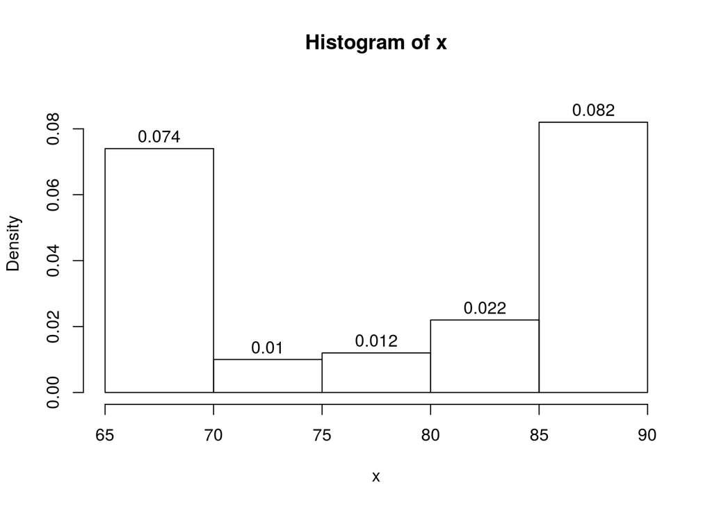

## Answerlist

- Evaluate $\text{prop}[\mathbf{x}<80]$.
- Evaluate $\text{prop}[\mathbf{x}>80]$.
- Evaluate $\text{prop}[|\mathbf{x}-77.5|<7.5]$.
- Evaluate $\text{prop}[|\mathbf{x}-80|>5]$.
- Evaluate boundary $b$ such that $\text{prop}[\mathbf{x}<b] = 0.48$.
- Evaluate boundary $b$ such that $\text{prop}[\mathbf{x}>b] = 0.63$.
- Evaluate radius $r$ such that $\text{prop}[|\mathbf{x}-75|<r] = 0.11$.
- Evaluate radius $r$ such that $\text{prop}[|\mathbf{x}-82.5|>r] = 0.89$.

# Solution

The first 4 questions involve adding up frequencies of the indicated intervals. The last 4 questions can be done by guessing and checking until something works.

## Answerlist

- There are 48 measurements less than 80. So, $\text{prop}[\mathbf{x}<80]=0.48$.
- There are 52 measurements more than 80. So, $\text{prop}[\mathbf{x}>80]=0.52$.
- There are 22 measurements closer than 7.5 units from 77.5. So, $\text{prop}[|\mathbf{x}-77.5|<7.5]=0.22$.
- There are 83 measurements further than 5 units from 80. So, $\text{prop}[|\mathbf{x}-80|>5]=0.83$.
- A boundary at $b=80$ has 48 measurements less than it. So, $\text{prop}[\mathbf{x}<80]=0.48$.
- A boundary at $b=70$ has 63 measurements more than it. So, $\text{prop}[\mathbf{x}>70]=0.63$.
- An interval with radius $r=5$ around center 75 contains 11 measurements. So, $\text{prop}[|\mathbf{x}-75|<5]=0.11$.
- An interval with radius $r=2.5$ around center 82.5 excludes 89 measurements. So, $\text{prop}[|\mathbf{x}-82.5|>2.5]=0.89$.

# Meta-information

extype: cloze exclozetype: num|num|num|num|num|num|num|num exsolution: 0.48|0.52|0.22|0.83|80|70|5|2.5 exname: read_histogram extol: 0.001 exextra[numwidth]: 999